# SolutionGood

Yu-Chen Xue

2018年6月4日

# MZines4You – Solutions

##### Dateset source:

http://logisticregressionanalysis.com/303-what-a-logistic-regression-data-set-looks-like-an-example/

##### Dataset introduction

- Household Income (Income; rounded to the nearest $1,000.00)
- Gender (IsFemale = 1 if the person is female, 0 otherwise)
- Marital Status (IsMarried = 1 if married, 0 otherwise)
- College Educated (HasCollege = 1 if has one or more years of college education, 0 otherwise)
- Employed in a Profession (IsProfessional = 1 if employed in a profession, 0 otherwise)
- Retired (IsRetired = 1 if retired, 0 otherwise)
- Not employed (Unemployed = 1 if not employed, 0 otherwise)
- Length of Residency in Current City (ResLength; in years)
- Dual Income if Married (Dual = 1 if dual income, 0 otherwise)
- Children (Minors = 1 if children under 18 are in the household, 0 otherwise)
- Home ownership (Own = 1 if own residence, 0 otherwise)
- Resident type (House = 1 if residence is a single family house, 0 otherwise)
- Race (White = 1 if race is white, 0 otherwise)
- Language (English = 1 is the primary language in the household is English, 0 otherwise)

## 載入資料集

```r
library(ggplot2)
library(readr)
KidCreative <- read_csv("D:/WORKSPACE/DATASETS/KidCreative.csv")
names(KidCreative)
```

```
##  [1] "Obs No."          "Buy"              "Income"
##  [4] "Is Female"        "Is Married"       "Has College"
##  [7] "Is Professional"  "Is Retired"       "Unemployed"
## [10] "Residence Length" "Dual Income"      "Minors"
## [13] "Own"              "House"            "White"
## [16] "English"          "Prev Child Mag"   "Prev Parent Mag"
```

```r
head(KidCreative)
```

```
## # A tibble: 6 x 18
##   `Obs No.`   Buy Income `Is Female` `Is Married` `Has College`
##       <int> <int>  <int>       <int>        <int>         <int>
## 1         1     0  24000           1            0             1
## 2         2     1  75000           1            1             1
## 3         3     0  46000           1            1             0
## 4         4     1  70000           0            1             0
## 5         5     0  43000           1            0             0
## 6         6     0  24000           1            1             0
## # ... with 12 more variables: `Is Professional` <int>, `Is Retired` <int>,
## #   Unemployed <int>, `Residence Length` <int>, `Dual Income` <int>,
## #   Minors <int>, Own <int>, House <int>, White <int>, English <int>,
## #   `Prev Child Mag` <int>, `Prev Parent Mag` <int>
```

## 採用變數Income做回歸模型

```r
KidCreative$Income <- as.numeric(KidCreative$Income)
model.income <- glm(Buy~ Income, KidCreative, family = "binomial")
summary(model.income)
```

```
##
## Call:
## glm(formula = Buy ~ Income, family = "binomial", data = KidCreative)
##
## Deviance Residuals:
##      Min        1Q    Median        3Q       Max
## -2.00280  -0.22466  -0.05466  -0.01655   2.87445
##
## Coefficients:
##               Estimate Std. Error z value Pr(>|z|)
## (Intercept) -9.344e+00  8.315e-01  -11.24   <2e-16 ***
## Income       1.494e-04  1.336e-05   11.18   <2e-16 ***
## ---
## Signif. codes:  0 '***' 0.001 '**' 0.01 '*' 0.05 '.' 0.1 ' ' 1
##
## (Dispersion parameter for binomial family taken to be 1)
##
##     Null deviance: 646.05  on 672  degrees of freedom
## Residual deviance: 249.32  on 671  degrees of freedom
## AIC: 253.32
##
## Number of Fisher Scoring iterations: 7
```

```r
anova(model.income)
```

```
## Analysis of Deviance Table
##
## Model: binomial, link: logit
##
## Response: Buy
##
## Terms added sequentially (first to last)
##
##
##        Df Deviance Resid. Df Resid. Dev
## NULL                     672     646.05
## Income  1   396.73       671     249.32
```

```r
coef(model.income)
```

```
##   (Intercept)        Income
## -9.3441458339  0.0001494027
```

## 仿照資料集的分佈，生成數列

```r
x.seq <- seq(0, 75000, 1000)
x.seq
```

```
##  [1]     0  1000  2000  3000  4000  5000  6000  7000  8000  9000 10000
## [12] 11000 12000 13000 14000 15000 16000 17000 18000 19000 20000 21000
## [23] 22000 23000 24000 25000 26000 27000 28000 29000 30000 31000 32000
## [34] 33000 34000 35000 36000 37000 38000 39000 40000 41000 42000 43000
## [45] 44000 45000 46000 47000 48000 49000 50000 51000 52000 53000 54000
## [56] 55000 56000 57000 58000 59000 60000 61000 62000 63000 64000 65000
## [67] 66000 67000 68000 69000 70000 71000 72000 73000 74000 75000
```

## 借助上述數列來做預測

```r
pred.income <- predict(model.income, list(Income=x.seq),type="response")
pred.income
```

```
##            1            2            3            4            5
## 8.746837e-05 1.015616e-04 1.179254e-04 1.369254e-04 1.589861e-04
##            6            7            8            9           10
## 1.846005e-04 2.143407e-04 2.488711e-04 2.889627e-04 3.355107e-04
##           11           12           13           14           15
## 3.895540e-04 4.522985e-04 5.251439e-04 6.097143e-04 7.078944e-04
##           16           17           18           19           20
## 8.218711e-04 9.541815e-04 1.107768e-03 1.286045e-03 1.492970e-03
##           21           22           23           24           25
## 1.733131e-03 2.011847e-03 2.335280e-03 2.710568e-03 3.145976e-03
##           26           27           28           29           30
## 3.651069e-03 4.236912e-03 4.916294e-03 5.703989e-03 6.617051e-03
##           31           32           33           34           35
## 7.675142e-03 8.900910e-03 1.032041e-02 1.196354e-02 1.386463e-02
##           36           37           38           39           40
## 1.606289e-02 1.860313e-02 2.153628e-02 2.492017e-02 2.882009e-02
##           41           42           43           44           45
## 3.330948e-02 3.847050e-02 4.439445e-02 5.118205e-02 5.894341e-02
##           46           47           48           49           50
## 6.779763e-02 7.787183e-02 8.929958e-02 1.022185e-01 1.167667e-01
##           51           52           53           54           55
## 1.330785e-01 1.512788e-01 1.714759e-01 1.937538e-01 2.181640e-01
##           56           57           58           59           60
## 2.447160e-01 2.733697e-01 3.040280e-01 3.365321e-01 3.706605e-01
##           61           62           63           64           65
## 4.061313e-01 4.426093e-01 4.797171e-01 5.170500e-01 5.541936e-01
##           66           67           68           69           70
## 5.907416e-01 6.263137e-01 6.605705e-01 6.932251e-01 7.240505e-01
##           71           72           73           74           75
## 7.528826e-01 7.796192e-01 8.042153e-01 8.266765e-01 8.470510e-01
##           76
## 8.654204e-01
```

## 將預測結果用圖來呈現

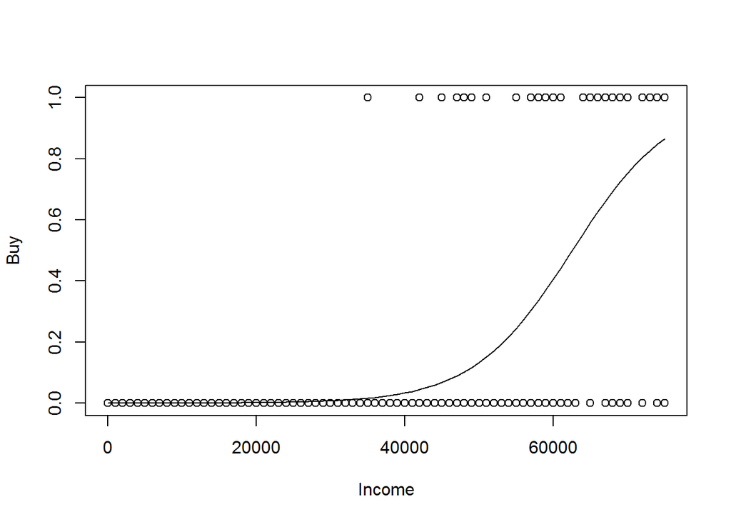

```r
plot(KidCreative$Income, KidCreative$Buy, pch = 1, xlab = "Income", ylab = "Buy")
lines(x.seq, pred.income)
```

## 收入大於63000的人群比較有可能購買雜誌

```r
predict(model.income, list(Income=63000),type="response")
```

```
##       1
## 0.51705
```

## Model2：採用變數Dual Income, Own做回歸模型並進行預測

```r
model2 <- glm(Buy~ `Dual Income`*Own , KidCreative, family = "binomial", x=TRUE)
summary(model2)
```

```
##
## Call:
## glm(formula = Buy ~ `Dual Income` * Own, family = "binomial",
##     data = KidCreative, x = TRUE)
##
## Deviance Residuals:
##     Min       1Q   Median       3Q      Max
## -1.1945  -0.6945  -0.3320  -0.3320   2.4190
##
## Coefficients:
##                   Estimate Std. Error z value Pr(>|z|)
## (Intercept)        -2.8707     0.2298 -12.490  < 2e-16 ***
## `Dual Income`       1.5715     0.3986   3.942 8.07e-05 ***
## Own                 1.9834     0.2940   6.746 1.52e-11 ***
## `Dual Income`:Own  -0.6441     0.4822  -1.336    0.182
## ---
## Signif. codes:  0 '***' 0.001 '**' 0.01 '*' 0.05 '.' 0.1 ' ' 1
##
## (Dispersion parameter for binomial family taken to be 1)
##
##     Null deviance: 646.05  on 672  degrees of freedom
## Residual deviance: 526.57  on 669  degrees of freedom
## AIC: 534.57
##
## Number of Fisher Scoring iterations: 5
```

```r
anova(model2)
```

```
## Analysis of Deviance Table
##
## Model: binomial, link: logit
##
## Response: Buy
##
## Terms added sequentially (first to last)
##
##
##                   Df Deviance Resid. Df Resid. Dev
## NULL                                672     646.05
## `Dual Income`      1   56.355       671     589.70
## Own                1   61.379       670     528.32
## `Dual Income`:Own  1    1.747       669     526.57
```

```r
coef(model2)
```

```
##       (Intercept)     `Dual Income`               Own `Dual Income`:Own
##        -2.8707358         1.5714528         1.9834326        -0.6441443
```

```r
exp(coef(model2))
```

```
##       (Intercept)     `Dual Income`               Own `Dual Income`:Own
##        0.05665722        4.81363635        7.26764705        0.52511170
```

```r
predict(model2, list( `Dual Income`=1, Own=1),type="response")
```

```
##    1
## 0.51
```

## Model3：採用變數Dual Income, Is Married, Is Female, Prev Child Mag做回歸模型並進行預測

```r
model3 <- glm(Buy~ `Dual Income`*`Is Married`*`Is Female`*`Prev Child Mag`, KidCreative, family = "binomial")
summary(model3)
```

```
##
## Call:
## glm(formula = Buy ~ `Dual Income` * `Is Married` * `Is Female` *
##     `Prev Child Mag`, family = "binomial", data = KidCreative)
##
## Deviance Residuals:
##     Min       1Q   Median       3Q      Max
## -2.1899  -0.4355  -0.4355  -0.3132   2.4655
##
## Coefficients: (1 not defined because of singularities)
##                                                           Estimate
## (Intercept)                                               -2.99016
## `Dual Income`                                              2.07387
## `Is Married`                                               1.77377
## `Is Female`                                                0.68233
## `Prev Child Mag`                                           1.78619
## `Dual Income`:`Is Married`                                -1.30946
## `Dual Income`:`Is Female`                                 -0.45918
## `Is Married`:`Is Female`                                   0.01277
## `Dual Income`:`Prev Child Mag`                            -4.36802
## `Is Married`:`Prev Child Mag`                             13.99627
## `Is Female`:`Prev Child Mag`                              -1.96326
## `Dual Income`:`Is Married`:`Is Female`                    -0.39703
## `Dual Income`:`Is Married`:`Prev Child Mag`              -11.65560
## `Dual Income`:`Is Female`:`Prev Child Mag`                19.80431
## `Is Married`:`Is Female`:`Prev Child Mag`                -14.68420
## `Dual Income`:`Is Married`:`Is Female`:`Prev Child Mag`         NA
##                                                         Std. Error z value
## (Intercept)                                                0.34161  -8.753
## `Dual Income`                                              0.90371   2.295
## `Is Married`                                               0.52795   3.360
## `Is Female`                                                0.41781   1.633
## `Prev Child Mag`                                           0.74164   2.408
## `Dual Income`:`Is Married`                                 1.02794  -1.274
## `Dual Income`:`Is Female`                                  1.27458  -0.360
## `Is Married`:`Is Female`                                   0.64845   0.020
## `Dual Income`:`Prev Child Mag`                          1081.13825  -0.004
## `Is Married`:`Prev Child Mag`                            624.19440   0.022
## `Is Female`:`Prev Child Mag`                               1.30047  -1.510
## `Dual Income`:`Is Married`:`Is Female`                     1.41693  -0.280
```

[output cut: 16 more lines]

```
## `Dual Income`:`Is Married`:`Is Female`                   0.77932
## `Dual Income`:`Is Married`:`Prev Child Mag`              0.98947
## `Dual Income`:`Is Female`:`Prev Child Mag`               0.97469
## `Is Married`:`Is Female`:`Prev Child Mag`                0.98123
## `Dual Income`:`Is Married`:`Is Female`:`Prev Child Mag`       NA
## ---
## Signif. codes:  0 '***' 0.001 '**' 0.01 '*' 0.05 '.' 0.1 ' ' 1
##
## (Dispersion parameter for binomial family taken to be 1)
##
##     Null deviance: 646.05  on 672  degrees of freedom
## Residual deviance: 525.53  on 658  degrees of freedom
## AIC: 555.53
##
## Number of Fisher Scoring iterations: 13
```

```r
anova(model3)
```

```
## Analysis of Deviance Table
##
## Model: binomial, link: logit
##
## Response: Buy
##
## Terms added sequentially (first to last)
##
##
##                                                         Df Deviance
## NULL
## `Dual Income`                                            1   56.355
## `Is Married`                                             1   30.498
## `Is Female`                                              1    2.190
## `Prev Child Mag`                                         1    9.959
## `Dual Income`:`Is Married`                               1    5.187
## `Dual Income`:`Is Female`                                1    0.503
## `Is Married`:`Is Female`                                 1    0.078
## `Dual Income`:`Prev Child Mag`                           1    2.305
## `Is Married`:`Prev Child Mag`                            1    0.382
## `Is Female`:`Prev Child Mag`                             1    1.134
## `Dual Income`:`Is Married`:`Is Female`                   1    0.018
## `Dual Income`:`Is Married`:`Prev Child Mag`              1    0.425
## `Dual Income`:`Is Female`:`Prev Child Mag`               1    9.909
## `Is Married`:`Is Female`:`Prev Child Mag`                1    1.583
## `Dual Income`:`Is Married`:`Is Female`:`Prev Child Mag`  0    0.000
##                                                         Resid. Df
## NULL                                                          672
## `Dual Income`                                                 671
## `Is Married`                                                  670
## `Is Female`                                                   669
## `Prev Child Mag`                                              668
## `Dual Income`:`Is Married`                                    667
## `Dual Income`:`Is Female`                                     666
## `Is Married`:`Is Female`                                      665
## `Dual Income`:`Prev Child Mag`                                664
## `Is Married`:`Prev Child Mag`                                 663
## `Is Female`:`Prev Child Mag`                                  662
## `Dual Income`:`Is Married`:`Is Female`                        661
## `Dual Income`:`Is Married`:`Prev Child Mag`                   660
## `Dual Income`:`Is Female`:`Prev Child Mag`                    659
## `Is Married`:`Is Female`:`Prev Child Mag`                     658
## `Dual Income`:`Is Married`:`Is Female`:`Prev Child Mag`       658
##                                                         Resid. Dev
## NULL                                                        646.05
## `Dual Income`                                               589.70
## `Is Married`                                                559.20
## `Is Female`                                                 557.01
## `Prev Child Mag`                                            547.05
## `Dual Income`:`Is Married`                                  541.86
## `Dual Income`:`Is Female`                                   541.36
## `Is Married`:`Is Female`                                    541.28
## `Dual Income`:`Prev Child Mag`                              538.98
## `Is Married`:`Prev Child Mag`                               538.59
## `Is Female`:`Prev Child Mag`                                537.46
## `Dual Income`:`Is Married`:`Is Female`                      537.44
## `Dual Income`:`Is Married`:`Prev Child Mag`                 537.02
## `Dual Income`:`Is Female`:`Prev Child Mag`                  527.11
## `Is Married`:`Is Female`:`Prev Child Mag`                   525.53
## `Dual Income`:`Is Married`:`Is Female`:`Prev Child Mag`     525.53
```

```r
coef(model3)
```

```
##                                             (Intercept)
##                                             -2.99016123
##                                           `Dual Income`
##                                              2.07387050
##                                            `Is Married`
##                                              1.77376590
##                                             `Is Female`
##                                              0.68232678
##                                        `Prev Child Mag`
##                                              1.78618842
##                              `Dual Income`:`Is Married`
##                                             -1.30946030
##                               `Dual Income`:`Is Female`
##                                             -0.45918323
##                                `Is Married`:`Is Female`
##                                              0.01277162
##                          `Dual Income`:`Prev Child Mag`
##                                             -4.36802500
##                           `Is Married`:`Prev Child Mag`
##                                             13.99627468
##                            `Is Female`:`Prev Child Mag`
##                                             -1.96326063
##                  `Dual Income`:`Is Married`:`Is Female`
##                                             -0.39703452
##             `Dual Income`:`Is Married`:`Prev Child Mag`
##                                            -11.65560016
##              `Dual Income`:`Is Female`:`Prev Child Mag`
##                                             19.80431216
##               `Is Married`:`Is Female`:`Prev Child Mag`
##                                            -14.68419991
## `Dual Income`:`Is Married`:`Is Female`:`Prev Child Mag`
##                                                      NA
```

```r
exp(coef(model3))
```

```
##                                             (Intercept)
##                                            5.027933e-02
##                                           `Dual Income`
##                                            7.955556e+00
##                                            `Is Married`
##                                            5.893004e+00
##                                             `Is Female`
##                                            1.978476e+00
##                                        `Prev Child Mag`
##                                            5.966667e+00
##                              `Dual Income`:`Is Married`
##                                            2.699657e-01
##                               `Dual Income`:`Is Female`
##                                            6.317995e-01
##                                `Is Married`:`Is Female`
##                                            1.012854e+00
##                          `Dual Income`:`Prev Child Mag`
##                                            1.267625e-02
##                           `Is Married`:`Prev Child Mag`
##                                            1.198133e+06
##                            `Is Female`:`Prev Child Mag`
##                                            1.403999e-01
##                  `Dual Income`:`Is Married`:`Is Female`
##                                            6.723108e-01
##             `Dual Income`:`Is Married`:`Prev Child Mag`
##                                            8.670361e-06
##              `Dual Income`:`Is Female`:`Prev Child Mag`
##                                            3.989362e+08
##               `Is Married`:`Is Female`:`Prev Child Mag`
##                                            4.195010e-07
## `Dual Income`:`Is Married`:`Is Female`:`Prev Child Mag`
##                                                      NA
```

```r
predict(model3, list(`Dual Income`=1, `Is Married`=1, `Is Female`=1, `Prev Child Mag`=1),type="response")
```

```
##         1
## 0.9090909
```

## Model4：採用變數Income, Is Female, Prev Child Mag做回歸模型並進行預測

```r
model4 <- glm(Buy~ Income*`Is Female`*`Prev Child Mag`, KidCreative, family = "binomial")
summary(model4)
```

```
##
## Call:
## glm(formula = Buy ~ Income * `Is Female` * `Prev Child Mag`,
##     family = "binomial", data = KidCreative)
##
## Deviance Residuals:
##      Min        1Q    Median        3Q       Max
## -2.28758  -0.14823  -0.03060  -0.00535   2.36912
##
## Coefficients:
##                                       Estimate Std. Error z value Pr(>|z|)
## (Intercept)                         -1.244e+01  2.078e+00  -5.986 2.16e-09
## Income                               1.835e-04  3.042e-05   6.032 1.61e-09
## `Is Female`                          2.967e+00  2.397e+00   1.238    0.216
## `Prev Child Mag`                    -6.429e+02  4.670e+04  -0.014    0.989
## Income:`Is Female`                  -2.335e-05  3.667e-05  -0.637    0.524
## Income:`Prev Child Mag`              1.030e-02  7.452e-01   0.014    0.989
## `Is Female`:`Prev Child Mag`         6.473e+02  4.670e+04   0.014    0.989
## Income:`Is Female`:`Prev Child Mag` -1.036e-02  7.452e-01  -0.014    0.989
##
## (Intercept)                         ***
## Income                              ***
## `Is Female`
## `Prev Child Mag`
## Income:`Is Female`
## Income:`Prev Child Mag`
## `Is Female`:`Prev Child Mag`
## Income:`Is Female`:`Prev Child Mag`
## ---
## Signif. codes:  0 '***' 0.001 '**' 0.01 '*' 0.05 '.' 0.1 ' ' 1
##
## (Dispersion parameter for binomial family taken to be 1)
##
##     Null deviance: 646.05  on 672  degrees of freedom
## Residual deviance: 221.84  on 665  degrees of freedom
## AIC: 237.84
##
## Number of Fisher Scoring iterations: 21
```

```r
anova(model4)
```

```
## Analysis of Deviance Table
##
## Model: binomial, link: logit
##
## Response: Buy
##
## Terms added sequentially (first to last)
##
##
##                                     Df Deviance Resid. Df Resid. Dev
## NULL                                                  672     646.05
## Income                               1   396.73       671     249.32
## `Is Female`                          1    16.19       670     233.14
## `Prev Child Mag`                     1     4.00       669     229.14
## Income:`Is Female`                   1     1.47       668     227.67
## Income:`Prev Child Mag`              1     0.67       667     227.00
## `Is Female`:`Prev Child Mag`         1     0.64       666     226.36
## Income:`Is Female`:`Prev Child Mag`  1     4.52       665     221.84
```

```r
coef(model4)
```

```
##                         (Intercept)                              Income
##                       -1.243737e+01                        1.834881e-04
##                         `Is Female`                    `Prev Child Mag`
##                        2.967394e+00                       -6.429264e+02
##                  Income:`Is Female`             Income:`Prev Child Mag`
##                       -2.334668e-05                        1.030071e-02
##        `Is Female`:`Prev Child Mag` Income:`Is Female`:`Prev Child Mag`
##                        6.472722e+02                       -1.036354e-02
```

```r
exp(coef(model4))
```

```
##                         (Intercept)                              Income
##                        3.967534e-06                        1.000184e+00
##                         `Is Female`                    `Prev Child Mag`
##                        1.944119e+01                       6.034324e-280
##                  Income:`Is Female`             Income:`Prev Child Mag`
##                        9.999767e-01                        1.010354e+00
##        `Is Female`:`Prev Child Mag` Income:`Is Female`:`Prev Child Mag`
##                       1.278582e+281                        9.896900e-01
```

```r
predict(model4, list(Income=63000, `Is Female`=1, `Prev Child Mag`=1),type="response")
```

```
##        1
## 0.732303
```

```r
model5 <- glm(Buy~ Income*`Prev Child Mag`, KidCreative, family = "binomial")
summary(model5)
```

```
##
## Call:
## glm(formula = Buy ~ Income * `Prev Child Mag`, family = "binomial",
##     data = KidCreative)
##
## Deviance Residuals:
##      Min        1Q    Median        3Q       Max
## -2.23298  -0.20981  -0.05396  -0.01450   2.57702
##
## Coefficients:
##                           Estimate Std. Error z value Pr(>|z|)
## (Intercept)             -9.779e+00  9.305e-01 -10.509   <2e-16 ***
## Income                   1.546e-04  1.483e-05  10.425   <2e-16 ***
## `Prev Child Mag`         3.395e+00  2.032e+00   1.671   0.0948 .
## Income:`Prev Child Mag` -3.744e-05  3.465e-05  -1.081   0.2799
## ---
## Signif. codes:  0 '***' 0.001 '**' 0.01 '*' 0.05 '.' 0.1 ' ' 1
##
## (Dispersion parameter for binomial family taken to be 1)
##
##     Null deviance: 646.05  on 672  degrees of freedom
## Residual deviance: 243.61  on 669  degrees of freedom
## AIC: 251.61
##
## Number of Fisher Scoring iterations: 7
```

```r
anova(model5)
```

```
## Analysis of Deviance Table
##
## Model: binomial, link: logit
##
## Response: Buy
##
## Terms added sequentially (first to last)
##
##
##                         Df Deviance Resid. Df Resid. Dev
## NULL                                      672     646.05
## Income                   1   396.73       671     249.32
## `Prev Child Mag`         1     4.72       670     244.61
## Income:`Prev Child Mag`  1     1.00       669     243.61
```

```r
coef(model5)
```

```
##             (Intercept)                  Income        `Prev Child Mag`
##           -9.778978e+00            1.546492e-04            3.395219e+00
## Income:`Prev Child Mag`
##           -3.744138e-05
```

```r
exp(coef(model5))
```

```
##             (Intercept)                  Income        `Prev Child Mag`
##            5.662963e-05            1.000155e+00            2.982118e+01
## Income:`Prev Child Mag`
##            9.999626e-01
```

```r
predict(model5, list(Income=63000, `Prev Child Mag`=1),type="response")
```

```
##         1
## 0.7311244
```